# QTM 151 - Quiz 2

**Submit as an HTML file**

This quiz is open book

- You can use the lecture notes
- You will get partial credit for attempting the questions
- To get full credit, the code should run as intended
- You should NOT communicate with other students

Print the following message:

"I will abide by Emory's code of conduct"

```python
# Write your answer here:

print("Gabe Vu")
```

```
Gabe Vu
```

Import libraries

```python
import numpy as np
import matplotlib.pyplot as plt
import pandas as pd
```

Preliminary check: can you load the data?

In the .zip file you opened, there is a comma-separated values file named  
"fifa23_players.csv". Using Pandas, create a DataFrame object by reading in this file.

If you get an error, you must figure out what the issue is.

**Note**: This cell is just to test whether you can access the data correctly. If everything works, you can copy and paste the code later in the notebook if you prefer.

```python
# make sure you can load the data
Quiz_2_df = pd.read_csv("data_quiz/fifa23_players.csv")
```

(1) Debugging code

The following code cell causes an error. Determine what causes the error, and add a comment to the offending line, explaining what the issue is (imagine you are trying to help a struggling classmate)

Then in the following blank code cell, put a corrected version of the code cell which does not cause an error, and run it.

```python
def test_grade(numeric_grade):
    if grade >= 55: #grade right here is actually supposed to be "numeric_grade" because it's been defined (See next line)
        #as an argument inside the parenthesis (See Next Line)
        #"grade" here is an undefined object (See next line)
        return "status = pass"
    else:
        return "status = fail"

student_grade = 55
print(test_grade(student_grade))
```

```
---------------------------------------------------------------------------
NameError                                 Traceback (most recent call last)
Cell In[10], line 10
      7         return "status = fail"
      9 student_grade = 55
---> 10 print(test_grade(student_grade))

Cell In[10], line 2, in test_grade(numeric_grade)
      1 def test_grade(numeric_grade):
----> 2     if grade >= 55: #grade right here is actually supposed to be "numeric_grade" because it's been defined (See next line)
      3         #as an argument inside the parenthesis (See Next Line)
      4         #"grade" here is an undefined object (See next line)
      5         return "status = pass"
      6     else:

NameError: name 'grade' is not defined
```

```python
# your corrected version of the above code cell
def test_grade(numeric_grade):
    if numeric_grade >= 55:
        return "status = pass"
    else:
        return "status = fail"

student_grade = 55
print(test_grade(student_grade))
```

```
status = pass
```

(2) More debugging

The following code cell **attempts** to define a Numpy array with 3 elements:

- $z_1 = 1^2 + 2^2 = 5$
- $z_2 = 3^2 + 4^2 = 25$
- $z_3 = 5^2 + 2^2 = 29$

However, when you run the cell, you will **not** see these three numbers.

Determine what causes the behavior, explaining why the code is not correct (imagine you are trying to help a struggling classmate)

Then in the following blank code cell, put a corrected version of the code cell which gives the correct output, and run it.

```python
x_vals = [1, 3, 5]
y_vals = [2, 4, 2]

z_vals = np.array(x_vals + y_vals)**2 #This is an error (See next line)
#because we're only combining the arrays together into 1 array then multiplying them by ^2
print(z_vals)
```

```
[ 1  9 25  4 16  4]
```

```python
# your corrected version of the above code cell
x_vals = [1, 3, 5]
y_vals = [2, 4, 2]

z_vals = np.array(x_vals)**2 + np.array(y_vals)**2
print(z_vals)
```

```
[ 5 25 29]
```

In the .zip file you opened, there is a comma-separated values file named  
"fifa23_players.csv". Using Pandas, create a DataFrame object by reading in this file.

**Hint**: Lectures 9 and 11 will be helpful for the rest of the questions!

(3) Using `.query`

- View the dataset and look for the name of the column corresponding to height in cm (centimeters). (No code/output is expected for this part).
- Using the `.query` method, extract the subset of players whose value of the height variable is **greater than** 175 and assign it to a new DataFrame.
- **Note**: The relevant column name has a space (and parentheses!), so you will need to use the backtick/grave accent (`) in your code.
- Using `.shape`, define an integer variable `num_tall` which is the number of players who are above this height threshold.

```python
# Write your own code

Tall_People = Quiz_2_df.query("`Height(in cm)` > 175")
Tall_People

num_tall = (Tall_People.shape[0])
num_tall
```

[output not shown]

(4) Create a function and apply it to a column

Step 1:

- Define a function with a single input argument "Overall" which classifies each player as follows:
  - If "Overall > 85", the function returns the string "Top Performer"
  - If "Overall <= 85", the function returns the string "Non Top-Performer"

Step 2:

- Extract the column "Overall" from the FIFA players DataFrame, and assign it to a variable (which should be a Pandas Series)
- Using the Pandas `.apply` method, create a new Pandas Series called "player_classification" which contains the appropriate string for each player.

```python
# Write your own code
Question_4 = Quiz_2_df
def performance(Overall):
    if Overall > 85:
        return "Top Performer"
    else:
        return "Non Top-Performer"

Question_4["Player_Classification"] = Question_4["Overall"].apply(performance)

Question_4
```

|  | Unnamed: 0 | Known As | Full Name | Overall | Potential | Value(in Euro) | Positions Played | Best Position | Nationality | Image Link | ... | Weak Foot Rating | Skill Moves | International Reputation | National Team Name | National Team Image Link | National Team Position | National Team Jersey Number | Attacking Work Rate | Defensive Work Rate | Player_Classification |
| --- | --- | --- | --- | --- | --- | --- | --- | --- | --- | --- | --- | --- | --- | --- | --- | --- | --- | --- | --- | --- | --- |
| 0 | 0 | L. Messi | Lionel Messi | 91 | 91 | 54000000 | RW | CAM | Argentina | https://cdn.sofifa.net/players/158/023/23_60.png | ... | 4 | 4 | 5 | Argentina | https://cdn.sofifa.net/flags/ar.png | RW | 10 | Low | Low | Top Performer |
| 1 | 1 | K. Benzema | Karim Benzema | 91 | 91 | 64000000 | CF,ST | CF | France | https://cdn.sofifa.net/players/165/153/23_60.png | ... | 4 | 4 | 4 | France | https://cdn.sofifa.net/flags/fr.png | ST | 19 | Medium | Medium | Top Performer |
| 2 | 2 | R. Lewandowski | Robert Lewandowski | 91 | 91 | 84000000 | ST | ST | Poland | https://cdn.sofifa.net/players/188/545/23_60.png | ... | 4 | 4 | 5 | Poland | https://cdn.sofifa.net/flags/pl.png | ST | 9 | High | Medium | Top Performer |
| 3 | 3 | K. De Bruyne | Kevin De Bruyne | 91 | 91 | 107500000 | CM,CAM | CM | Belgium | https://cdn.sofifa.net/players/192/985/23_60.png | ... | 5 | 4 | 4 | Belgium | https://cdn.sofifa.net/flags/be.png | RF | 7 | High | High | Top Performer |
| 4 | 4 | K. Mbappé | Kylian Mbappé | 91 | 95 | 190500000 | ST,LW | ST | France | https://cdn.sofifa.net/players/231/747/23_60.png | ... | 4 | 5 | 4 | France | https://cdn.sofifa.net/flags/fr.png | ST | 10 | High | Low | Top Performer |
| ... | ... | ... | ... | ... | ... | ... | ... | ... | ... | ... | ... | ... | ... | ... | ... | ... | ... | ... | ... | ... | ... |
| 18534 | 18534 | D. Collins | Darren Collins | 47 | 56 | 110000 | ST,RM | CAM | Republic of Ireland | https://cdn.sofifa.net/players/243/725/23_60.png | ... | 3 | 2 | 1 | - | - | - | - | Medium | Medium | Non Top-Performer |
| 18535 | 18535 | Yang Dejiang | Dejiang Yang | 47 | 57 | 90000 | CDM | CDM | China PR | https://cdn.sofifa.net/players/261/933/23_60.png | ... | 3 | 2 | 1 | - | - | - | - | Medium | Medium | Non Top-Performer |
| 18536 | 18536 | L. Mullan | Liam Mullan | 47 | 67 | 130000 | CM | RM | Northern Ireland | https://cdn.sofifa.net/players/267/823/23_60.png | ... | 3 | 2 | 1 | - | - | - | - | High | Medium | Non Top-Performer |
| 18537 | 18537 | D. McCallion | Daithí McCallion | 47 | 61 | 100000 | CB | CB | Republic of Ireland | https://cdn.sofifa.net/players/267/824/23_60.png | ... | 3 | 2 | 1 | - | - | - | - | Medium | Medium | Non Top-Performer |
| 18538 | 18538 | N. Rabha | Nabin Rabha | 47 | 50 | 60000 | LB | LB | India | https://cdn.sofifa.net/players/261/424/23_60.png | ... | 3 | 2 | 1 | - | - | - | - | Medium | Medium | Non Top-Performer |

18539 rows × 34 columns

(5) Split a dataset into subsets

- We will continue using the DataFrame you read in from "fifa23_players.csv"
- Use `.shape` to define an integer variable called `n`, which is the total number of rows in this DataFrame.
- Use `numpy.random.uniform` to create a random sample of size `n` from the uniform distribution between 0 and 1. Then store these random numbers as a new column `random_var` to the original DataFrame.
- Use `.query` to extract all players with `random_var < 0.4`, and assign it to a new DataFrame called `groupA`
- Use `.query` to extract all players with `random_var >= 0.4`, and assign it to a new DataFrame called `groupB`.

**Note**: In this way, we are assigning roughly 40% of the players to Group A, and roughly 60% to Group B

```python
# Write your own code
n = Quiz_2_df.shape[0]
Quiz_2_df["random_var"] = np.random.uniform(0, 1, size=n)
groupA = Quiz_2_df.query("random_var < 0.4")
groupB = Quiz_2_df.query("random_var >= 0.4")

groupA
```

|  | Unnamed: 0 | Known As | Full Name | Overall | Potential | Value(in Euro) | Positions Played | Best Position | Nationality | Image Link | ... | Skill Moves | International Reputation | National Team Name | National Team Image Link | National Team Position | National Team Jersey Number | Attacking Work Rate | Defensive Work Rate | Player_Classification | random_var |
| --- | --- | --- | --- | --- | --- | --- | --- | --- | --- | --- | --- | --- | --- | --- | --- | --- | --- | --- | --- | --- | --- |
| 1 | 1 | K. Benzema | Karim Benzema | 91 | 91 | 64000000 | CF,ST | CF | France | https://cdn.sofifa.net/players/165/153/23_60.png | ... | 4 | 4 | France | https://cdn.sofifa.net/flags/fr.png | ST | 19 | Medium | Medium | Top Performer | 0.311588 |
| 2 | 2 | R. Lewandowski | Robert Lewandowski | 91 | 91 | 84000000 | ST | ST | Poland | https://cdn.sofifa.net/players/188/545/23_60.png | ... | 4 | 5 | Poland | https://cdn.sofifa.net/flags/pl.png | ST | 9 | High | Medium | Top Performer | 0.090834 |
| 8 | 8 | Cristiano Ronaldo | C. Ronaldo dos Santos Aveiro | 90 | 90 | 41000000 | ST | ST | Portugal | https://cdn.sofifa.net/players/020/801/23_60.png | ... | 5 | 5 | Portugal | https://cdn.sofifa.net/flags/pt.png | ST | 7 | High | Low | Top Performer | 0.356291 |
| 9 | 9 | V. van Dijk | Virgil van Dijk | 90 | 90 | 98000000 | CB | CB | Netherlands | https://cdn.sofifa.net/players/203/376/23_60.png | ... | 2 | 4 | Netherlands | https://cdn.sofifa.net/flags/nl.png | CB | 4 | Medium | High | Top Performer | 0.158494 |
| 11 | 11 | Neymar Jr | Neymar da Silva Santos Jr. | 89 | 89 | 99500000 | LW | LW | Brazil | https://cdn.sofifa.net/players/190/871/23_60.png | ... | 5 | 5 | - | https://cdn.sofifa.net/flags/br.png | - | - | High | Medium | Top Performer | 0.216900 |
| ... | ... | ... | ... | ... | ... | ... | ... | ... | ... | ... | ... | ... | ... | ... | ... | ... | ... | ... | ... | ... | ... |
| 18530 | 18530 | S. Bag | Sajal Bag | 48 | 61 | 110000 | CM,RM | RM | India | https://cdn.sofifa.net/players/270/739/23_60.png | ... | 2 | 1 | - | - | - | - | Medium | Medium | Non Top-Performer | 0.329267 |
| 18532 | 18532 | H. Singh | Harmanpreet Singh | 48 | 56 | 100000 | ST | ST | India | https://cdn.sofifa.net/players/259/745/23_60.png | ... | 2 | 1 | - | - | - | - | Medium | Low | Non Top-Performer | 0.375639 |
| 18535 | 18535 | Yang Dejiang | Dejiang Yang | 47 | 57 | 90000 | CDM | CDM | China PR | https://cdn.sofifa.net/players/261/933/23_60.png | ... | 2 | 1 | - | - | - | - | Medium | Medium | Non Top-Performer | 0.151462 |
| 18536 | 18536 | L. Mullan | Liam Mullan | 47 | 67 | 130000 | CM | RM | Northern Ireland | https://cdn.sofifa.net/players/267/823/23_60.png | ... | 2 | 1 | - | - | - | - | High | Medium | Non Top-Performer | 0.375886 |
| 18537 | 18537 | D. McCallion | Daithí McCallion | 47 | 61 | 100000 | CB | CB | Republic of Ireland | https://cdn.sofifa.net/players/267/824/23_60.png | ... | 2 | 1 | - | - | - | - | Medium | Medium | Non Top-Performer | 0.315421 |

7406 rows × 35 columns

(6) Create two scatter plots of the groups

- This question requires the two datasets you created in part (5)
- Use `matplotlib.pyplot.subplots` to create two side by side scatter plots (1 row, 2 columns)
- In the left figure, plot the columns `Age` vs. `Overall` for the data in `groupA` (so the horizontal axis will correspond to "Age")
- In the right figure, plot the columns `Age` vs. `Overall` for the data in `groupB` (so the horizontal axis will correspond to "Age")
- Label the axes for both plots. Create a title for **both** plots, indicating whether Group A or Group B is shown.

**Note**: If the assignment into groups was done randomly, then we expect that the scatter plots will be **very similar**

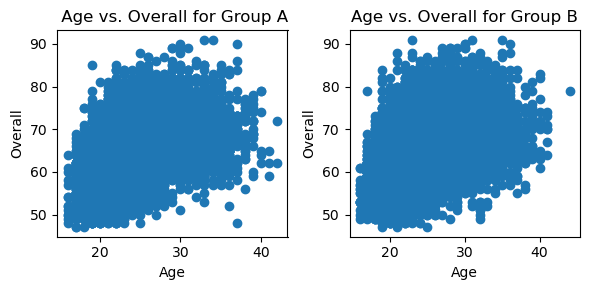

```python
# Your code here
fig, subfig_array = plt.subplots(nrows = 1, ncols = 2, figsize= (6, 3))

subfig_array[0].scatter(groupA['Age'], groupA['Overall'])
subfig_array[0].set_title(" Age vs. Overall for Group A")
subfig_array[0].set_xlabel("Age")
subfig_array[0].set_ylabel("Overall")

subfig_array[1].scatter(groupB['Age'], groupB['Overall'])
subfig_array[1].set_title("Age vs. Overall for Group B")
subfig_array[1].set_xlabel("Age")
subfig_array[1].set_ylabel("Overall")

plt.tight_layout()
plt.show()
```